# MixedRegression

Tim Schneegans

4 Januar 2021

```r
setwd("C:/Users/User/GitHub/WebET_Analysis")
# https://gist.github.com/stevenworthington/3178163
ipak <- function(pkg){
  new.pkg <- pkg[!(pkg %in% installed.packages()[, "Package"])]
  if (length(new.pkg))
    install.packages(new.pkg, dependencies = TRUE)
  sapply(pkg, require, character.only = TRUE)
}
ipak(c(
    'data.table',
    "dplyr",
    'Hmisc',

    "knitr",
    'readr',
    "rsq",
    'lme4',
    'nlme',
    'reshape',
    "ICC",
    'ggplot2',
    'GGally',
    'reshape2',
    'lme4',
    'compiler',
    'parallel',
    'boot',
    'lattice',
    "lmerTest", # Erhalte p-Werte
    "tinytex"
    )
)
```

```
## data.table      dplyr      Hmisc      knitr      readr        rsq       lme4
##       TRUE       TRUE       TRUE       TRUE       TRUE       TRUE       TRUE
##       nlme    reshape        ICC    ggplot2     GGally   reshape2       lme4
##       TRUE       TRUE       TRUE       TRUE       TRUE       TRUE       TRUE
##   compiler   parallel       boot    lattice   lmerTest    tinytex
##       TRUE       TRUE       TRUE       TRUE       TRUE       TRUE
```

```r
knitr::opts_chunk$set(echo = TRUE)
options(scipen=999) # Show R markdown output as Integers
```

# Prep data

```r
data_et_fix_raw <- read_csv('data_jupyter/data_et_fix.csv')
data_trial_fix_raw <- read_csv('data_jupyter/data_trial_fix.csv')
data_subject_raw <- read_csv('data_jupyter/data_subject.csv')
str(data_et_fix_raw)
```

```
## tibble [57,762 x 22] (S3: spec_tbl_df/tbl_df/tbl/data.frame)
##  $ x                        : num [1:57762] 0.481 0.508 0.501 0.502 0.503 ...
##  $ y                        : num [1:57762] 0.658 0.643 0.663 0.656 0.637 ...
##  $ t                        : num [1:57762] 373746 374247 374744 375206 375671 ...
##  $ t_task                   : num [1:57762] 1442 1943 2440 2902 3367 ...
##  $ run_id                   : num [1:57762] 1 1 1 1 1 1 1 1 1 1 ...
##  $ trial_index              : num [1:57762] 106 106 106 106 106 106 106 106 109 109 ...
##  $ task_nr                  : num [1:57762] 1 1 1 1 1 1 1 1 1 1 ...
##  $ chin                     : num [1:57762] 1 1 1 1 1 1 1 1 1 1 ...
##  $ chinFirst                : num [1:57762] 1 1 1 1 1 1 1 1 1 1 ...
##  $ trial_type               : chr [1:57762] "eyetracking-fix-object" "eyetracking-fix-object" "eyetracking-fix-object" "eyetracking-fix-object" ...
##  $ trial_duration           : num [1:57762] 5000 5000 5000 5000 5000 5000 5000 5000 5000 5000 ...
##  $ trial_duration_exact     : num [1:57762] 6337 6337 6337 6337 6337 ...
##  $ x_pos                    : num [1:57762] 0.5 0.5 0.5 0.5 0.5 0.5 0.5 0.5 0.2 0.2 ...
##  $ y_pos                    : num [1:57762] 0.5 0.5 0.5 0.5 0.5 0.5 0.5 0.5 0.8 0.8 ...
##  $ window_width             : num [1:57762] 1920 1920 1920 1920 1920 1920 1920 1920 1920 1920 ...
##  $ window_height            : num [1:57762] 1080 1080 1080 1080 1080 1080 1080 1080 1080 1080 ...
##  $ offset                   : num [1:57762] 0.159 0.143 0.163 0.156 0.137 ...
##  $ offset_px                : num [1:57762] 174 155 176 169 148 ...
##  $ x_mean                   : num [1:57762] 0.508 0.508 0.508 0.508 0.508 ...
##  $ y_mean                   : num [1:57762] 0.625 0.625 0.625 0.625 0.625 ...
##  $ distanceFromAVG_square   : num [1:57762] 0.001802 0.000315 0.001464 0.000995 0.000154 ...
##  $ distanceFromAVG_square_px: num [1:57762] 3934 369 1842 1262 251 ...
##  - attr(*, "spec")=
##   .. cols(
##   ..   x = col_double(),
##   ..   y = col_double(),
##   ..   t = col_double(),
##   ..   t_task = col_double(),
##   ..   run_id = col_double(),
##   ..   trial_index = col_double(),
##   ..   task_nr = col_double(),
##   ..   chin = col_double(),
##   ..   chinFirst = col_double(),
##   ..   trial_type = col_character(),
##   ..   trial_duration = col_double(),
##   ..   trial_duration_exact = col_double(),
##   ..   x_pos = col_double(),
##   ..   y_pos = col_double(),
##   ..   window_width = col_double(),
##   ..   window_height = col_double(),
##   ..   offset = col_double(),
##   ..   offset_px = col_double(),
##   ..   x_mean = col_double(),
##   ..   y_mean = col_double(),
##   ..   distanceFromAVG_square = col_double(),
##   ..   distanceFromAVG_square_px = col_double()
##   .. )
```

```r
names(data_trial_fix_raw)
```

```
##  [1] "run_id"                    "subject"
##  [3] "prolificID"                "chinFirst"
##  [5] "trial_index"               "task_nr"
##  [7] "rt"                        "stimulus"
##  [9] "key_press"                 "time_elapsed"
## [11] "recorded_at"               "window_width"
## [13] "window_height"             "success"
## [15] "chin"                      "x_pos"
## [17] "y_pos"                     "window_width_max"
## [19] "window_height_max"         "window_diagonal_max"
## [21] "window_diagonal"           "t_startTrial"
## [23] "trial_duration_exact"      "fixTask"
## [25] "withinTaskIndex"           "x_count"
## [27] "fps"                       "positionIndex"
## [29] "glasses_binary"            "offset"
## [31] "offset_px"                 "x_mean"
## [33] "y_mean"                    "x_mean_px"
## [35] "y_mean_px"                 "grand_deviation"
## [37] "distanceFromAVG_square"    "precision"
## [39] "distanceFromAVG_square_px" "precision_px"
## [41] "high_fps"
```

```r
str(data_trial_fix_raw)
```

```
## tibble [918 x 41] (S3: spec_tbl_df/tbl_df/tbl/data.frame)
##  $ run_id                   : num [1:918] 1 1 1 1 1 1 1 1 1 1 ...
##  $ subject                  : num [1:918] 229 229 229 229 229 229 229 229 229 229 ...
##  $ prolificID               : chr [1:918] "5fccc8ac636416a4288a9f3d" "5fccc8ac636416a4288a9f3d" "5fccc8ac636416a4288a9f3d" "5fccc8ac636416a4288a9f3d" ...
##  $ chinFirst                : num [1:918] 1 1 1 1 1 1 1 1 1 1 ...
##  $ trial_index              : num [1:918] 106 109 112 115 118 121 124 127 130 483 ...
##  $ task_nr                  : num [1:918] 1 1 1 1 1 1 1 1 1 3 ...
##  $ rt                       : logi [1:918] NA NA NA NA NA NA ...
##  $ stimulus                 : chr [1:918] "\"" "\"" "\"" "\"" ...
##  $ key_press                : logi [1:918] NA NA NA NA NA NA ...
##  $ time_elapsed             : num [1:918] 403171 413504 423714 433979 444254 ...
##  $ recorded_at              : POSIXct[1:918], format: "2021-01-17 19:11:32" "2021-01-17 19:11:32" ...
##  $ window_width             : num [1:918] 1920 1920 1920 1920 1920 1920 1920 1920 1920 1920 ...
##  $ window_height            : num [1:918] 1080 1080 1080 1080 1080 1080 1080 1080 1080 1080 ...
##  $ success                  : chr [1:918] "\"" "\"" "\"" "\"" ...
##  $ chin                     : num [1:918] 1 1 1 1 1 1 1 1 1 0 ...
##  $ x_pos                    : num [1:918] 0.5 0.2 0.2 0.5 0.5 0.8 0.2 0.8 0.8 0.5 ...
##  $ y_pos                    : num [1:918] 0.5 0.8 0.5 0.8 0.2 0.2 0.2 0.5 0.8 0.5 ...
##  $ window_width_max         : num [1:918] 1920 1920 1920 1920 1920 1920 1920 1920 1920 1920 ...
##  $ window_height_max        : num [1:918] 1080 1080 1080 1080 1080 1080 1080 1080 1080 1080 ...
##  $ window_diagonal_max      : num [1:918] 2203 2203 2203 2203 2203 ...
##  $ window_diagonal          : num [1:918] 2203 2203 2203 2203 2203 ...
##  $ t_startTrial             : num [1:918] 396834 407133 417418 427661 437944 ...
##  $ trial_duration_exact     : num [1:918] 6337 6371 6296 6318 6310 ...
##  $ fixTask                  : num [1:918] 1 1 1 1 1 1 1 1 1 1 ...
##  $ withinTaskIndex          : num [1:918] 1 2 3 4 5 6 7 8 9 1 ...
##  $ x_count                  : num [1:918] 13 13 13 13 13 13 13 13 13 13 ...
##  $ fps                      : num [1:918] 2.05 2.04 2.06 2.06 2.06 ...
##  $ positionIndex            : num [1:918] 4 6 3 7 1 2 0 5 8 4 ...
##  $ glasses_binary           : num [1:918] 1 1 1 1 1 1 1 1 1 1 ...
##  $ offset                   : num [1:918] 0.127 0.202 0.163 0.117 0.167 ...
##  $ offset_px                : num [1:918] 140 335 292 134 185 ...
##  $ x_mean                   : num [1:918] 0.508 0.359 0.346 0.523 0.502 ...
##  $ y_mean                   : num [1:918] 0.625 0.683 0.56 0.686 0.364 ...
##  $ x_mean_px                : num [1:918] 976 689 665 1005 964 ...
##  $ y_mean_px                : num [1:918] 675 738 605 741 393 ...
##  $ grand_deviation          : num [1:918] 0.126 0.197 0.158 0.116 0.164 ...
##  $ distanceFromAVG_square   : num [1:918] 0.00146 0.01013 0.01052 0.00207 0.00749 ...
##  $ precision                : num [1:918] 0.0382 0.1006 0.1026 0.0455 0.0865 ...
##  $ distanceFromAVG_square_px: num [1:918] 2216 33295 38161 2635 9854 ...
```

[output cut: 31 more lines]

```
##   ..   positionIndex = col_double(),
##   ..   glasses_binary = col_double(),
##   ..   offset = col_double(),
##   ..   offset_px = col_double(),
##   ..   x_mean = col_double(),
##   ..   y_mean = col_double(),
##   ..   x_mean_px = col_double(),
##   ..   y_mean_px = col_double(),
##   ..   grand_deviation = col_double(),
##   ..   distanceFromAVG_square = col_double(),
##   ..   precision = col_double(),
##   ..   distanceFromAVG_square_px = col_double(),
##   ..   precision_px = col_double(),
##   ..   high_fps = col_double()
##   .. )
```

```r
head(data_trial_fix_raw)
```

```
## # A tibble: 6 x 41
##   run_id subject prolificID chinFirst trial_index task_nr rt    stimulus
##    <dbl>   <dbl> <chr>          <dbl>       <dbl>   <dbl> <lgl> <chr>
## 1      1     229 5fccc8ac6~         1         106       1 NA    "\""
## 2      1     229 5fccc8ac6~         1         109       1 NA    "\""
## 3      1     229 5fccc8ac6~         1         112       1 NA    "\""
## 4      1     229 5fccc8ac6~         1         115       1 NA    "\""
## 5      1     229 5fccc8ac6~         1         118       1 NA    "\""
## 6      1     229 5fccc8ac6~         1         121       1 NA    "\""
## # ... with 33 more variables: key_press <lgl>, time_elapsed <dbl>,
## #   recorded_at <dttm>, window_width <dbl>, window_height <dbl>, success <chr>,
## #   chin <dbl>, x_pos <dbl>, y_pos <dbl>, window_width_max <dbl>,
## #   window_height_max <dbl>, window_diagonal_max <dbl>, window_diagonal <dbl>,
## #   t_startTrial <dbl>, trial_duration_exact <dbl>, fixTask <dbl>,
## #   withinTaskIndex <dbl>, x_count <dbl>, fps <dbl>, positionIndex <dbl>,
## #   glasses_binary <dbl>, offset <dbl>, offset_px <dbl>, x_mean <dbl>,
## #   y_mean <dbl>, x_mean_px <dbl>, y_mean_px <dbl>, grand_deviation <dbl>,
## #   distanceFromAVG_square <dbl>, precision <dbl>,
## #   distanceFromAVG_square_px <dbl>, precision_px <dbl>, high_fps <dbl>
```

## Add glasses to data_et_fix

```r
if ('glasses_binary' %in% names(data_trial_fix_raw))
    {data_trial_fix_raw = data_trial_fix_raw %>% select(!glasses_binary)}
data_trial_fix_raw = merge(
    data_trial_fix_raw,
    data_subject_raw %>%
        select(run_id, glasses_binary) %>%
        distinct(),
    by='run_id'
)
data_trial_fix_raw
```

[output not shown]

[output cut: 7337 more lines]

# Screening

```r
summary(data_et_fix_raw %>%
            select(x, y, t_task)
)
```

```
##        x                 y               t_task
##  Min.   :-0.5437   Min.   :-0.6310   Min.   :1000
##  1st Qu.: 0.3062   1st Qu.: 0.3241   1st Qu.:1992
##  Median : 0.5140   Median : 0.5107   Median :2988
##  Mean   : 0.5086   Mean   : 0.4943   Mean   :2992
##  3rd Qu.: 0.7089   3rd Qu.: 0.6670   3rd Qu.:3990
##  Max.   : 1.5063   Max.   : 1.5913   Max.   :5000
```

```r
summary(data_trial_fix_raw %>%
            select(run_id, offset, precision, fps)
)
```

```
##      run_id           offset          precision            fps
##  Min.   :   1.0   Min.   :0.02862   Min.   :0.00034   Min.   : 1.094
##  1st Qu.:  32.0   1st Qu.:0.08849   1st Qu.:0.05154   1st Qu.:10.904
##  Median :  66.0   Median :0.14623   Median :0.06932   Median :17.696
##  Mean   : 230.1   Mean   :0.19243   Mean   :0.08455   Mean   :17.398
##  3rd Qu.:  97.0   3rd Qu.:0.23745   3rd Qu.:0.09781   3rd Qu.:22.280
##  Max.   :2013.0   Max.   :1.28729   Max.   :0.59111   Max.   :35.857
##                   NA's   :90        NA's   :90        NA's   :90
```

## FPS for fixation task

```r
trialFPS = data_et_fix_raw %>%
    group_by(run_id, trial_index) %>%
    summarise(n = n())
trialFPS = merge(
    trialFPS,
    data_trial_fix_raw %>% select(run_id, trial_index, trial_duration_exact),
    by=c('run_id', 'trial_index'))
trialFPS$fps = 1000 * trialFPS$n / trialFPS$trial_duration_exact

if ('fps_fix' %in% names(data_subject_raw))
    {data_subject_raw = data_subject_raw %>% select(!fps_fix)}
data_subject_raw = merge(
    data_subject_raw,
    trialFPS %>% group_by(run_id) %>% summarise(fps_fix = mean(fps)),
    by='run_id'
)
summary(data_subject_raw$fps_fix)
```

```
##    Min. 1st Qu.  Median    Mean 3rd Qu.    Max.
##  0.6885  8.5321 14.2435 13.7513 17.2251 27.6598
```

## Low FPS or not following instructions

```r
data_subject_raw %>%
    select(run_id, triedChin, keptHead, fps_fix) %>%
    filter(
        triedChin==0 |
        keptHead==0 |
        fps_fix<3
        )
```

```
##   run_id triedChin keptHead   fps_fix
## 1      1         1        1 1.2163430
## 2     80         1        1 1.6495869
## 3     97         1        1 0.6885165
## 4   2012         1        1 0.9235609
```

## Trials with insanely high t_task

```r
high_t_task = data_et_fix_raw %>%
    filter(t_task>5500) %>%
    group_by(run_id, trial_index) %>%
    summarise(t_task_max = max(t_task))
if ('trial_duration_exact' %in% names(high_t_task))
    {high_t_task = high_t_task %>% select(!trial_duration_exact)}
high_t_task = merge(
    high_t_task,
    data_trial_fix_raw %>%
        select(run_id, trial_index, trial_duration_exact),
    by=c('run_id', 'trial_index')
)
unique(high_t_task$run_id)
```

```
## numeric(0)
```

```r
high_t_task
```

```
## [1] run_id               trial_index          t_task_max
## [4] trial_duration_exact
## <0 rows> (or 0-length row.names)
```

## Anyone without the full number of trials?

```r
# Number of trials per subject
ans = as.data.table(
    data_trial_fix_raw %>% select(run_id, trial_index, chin, withinTaskIndex)
    )[, count := uniqueN(trial_index), by = run_id]
ans %>%
    filter(count!=18)
```

```
## Empty data.table (0 rows and 5 cols): run_id,trial_index,chin,withinTaskIndex,count
```

## Glasses

```r
data_subject_raw %>%
    select(run_id, glasses_binary) %>%
    filter(is.na(glasses_binary))
```

```
##   run_id glasses_binary
## 1    131             NA
```

# Cleaning

## Subjects to exclude from screening

```r
excludedSubjects = c(1, 70, 80, 97, 131, 2012)
```

## data_trial_fix

```r
data_trial_fix = data_trial_fix_raw %>%
    filter(
        !is.na(precision) &
        !(run_id %in% excludedSubjects) &
        (trial_duration_exact<5100)
        )
print(paste('Raw: ', nrow(data_trial_fix_raw)))
```

```
## [1] "Raw:  918"
```

```r
print(paste('Cleaned: ', nrow(data_trial_fix)))
```

```
## [1] "Cleaned:  567"
```

## data_et_fix

On purpose, we don’t exclude specific x and y values, neither positive nor negative outliers

```r
data_et_fix = data_et_fix_raw %>%
    filter(
        !(run_id %in% excludedSubjects) &
        (t_task<5100)
        )
print(paste('Raw: ', nrow(data_et_fix_raw)))
```

```
## [1] "Raw:  57762"
```

```r
print(paste('Cleaned: ', nrow(data_et_fix)))
```

```
## [1] "Cleaned:  56501"
```

# Assumptions - Long Format

```r
predictors = c('withinTaskIndex', 'x_pos', 'y_pos', 'fps', 'glasses_binary', 'chin')
```

## Multicollinearity of the predictors

```r
correlation = cor(
    data_trial_fix %>%
        select(predictors),
    use = 'pairwise.complete.obs'
)
```

```
## Note: Using an external vector in selections is ambiguous.
## i Use `all_of(predictors)` instead of `predictors` to silence this message.
## i See <https://tidyselect.r-lib.org/reference/faq-external-vector.html>.
```

```r
symnum(correlation)
```

```
##                 w x y f g c
## withinTaskIndex 1
## x_pos             1
## y_pos               1
## fps                   1
## glasses_binary          1
## chin                      1
## attr(,"legend")
## [1] 0 ' ' 0.3 '.' 0.6 ',' 0.8 '+' 0.9 '*' 0.95 'B' 1
```

```r
correlation
```

```
##                 withinTaskIndex        x_pos         y_pos          fps
## withinTaskIndex     1.000000000  0.033454906 -0.0209175063 -0.019120166
## x_pos               0.033454906  1.000000000  0.0158523934  0.002353003
## y_pos              -0.020917506  0.015852393  1.0000000000 -0.021489471
## fps                -0.019120166  0.002353003 -0.0214894714  1.000000000
## glasses_binary     -0.002586590  0.004525798 -0.0002391491  0.076438987
## chin                0.004011161 -0.017282528 -0.0152053037  0.005080381
##                 glasses_binary         chin
## withinTaskIndex  -0.0025865901  0.004011161
## x_pos             0.0045257982 -0.017282528
## y_pos            -0.0002391491 -0.015205304
## fps               0.0764389865  0.005080381
## glasses_binary    1.0000000000  0.006804899
## chin              0.0068048994  1.000000000
```

## Standardized residuals

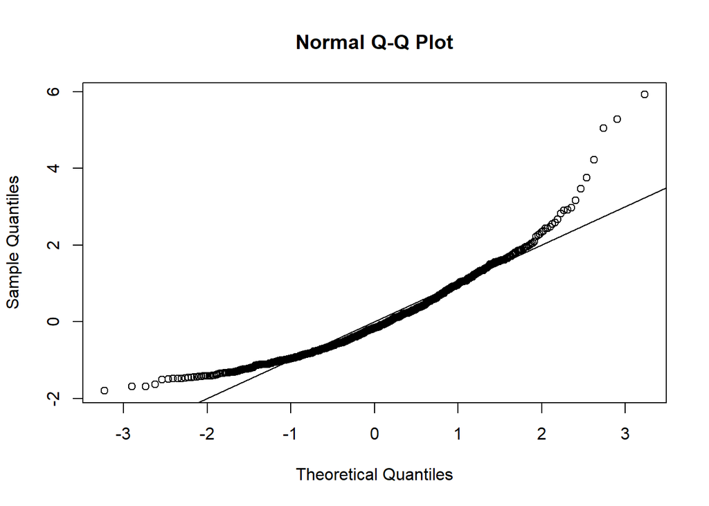

```r
random = rchisq(nrow(data_trial_fix_raw), 7)
fake = lm(
    random ~ .,
    data=data_trial_fix_raw %>% select(predictors)
    )

fitted = scale(fake$fitted.values)
# Studentized residuals
standardized = rstudent(fake)
qqnorm(standardized)
abline(0, 1)
```

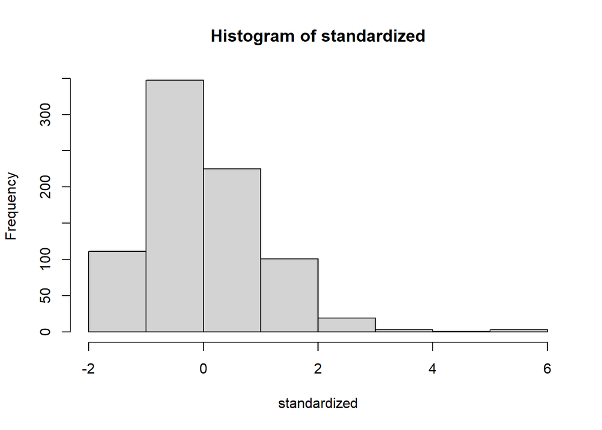

```r
hist(standardized)
```

## Heteroscedasticity

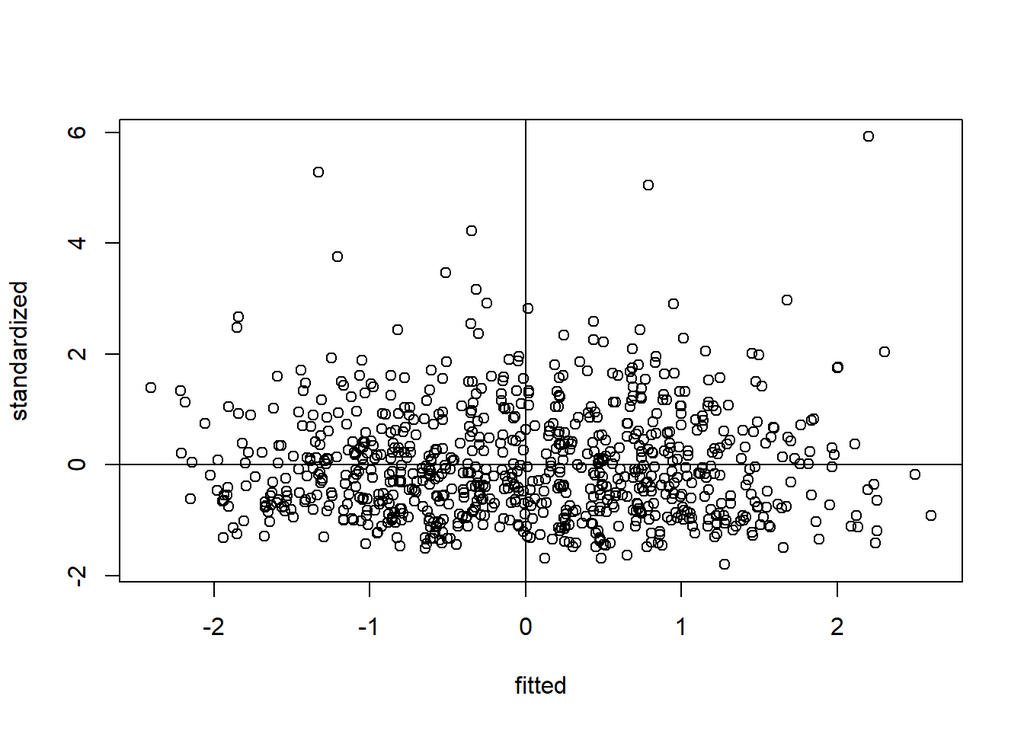

```r
plot(fitted, standardized)
abline(0, 0)
abline(v=0)
```

# Visualize Predictors

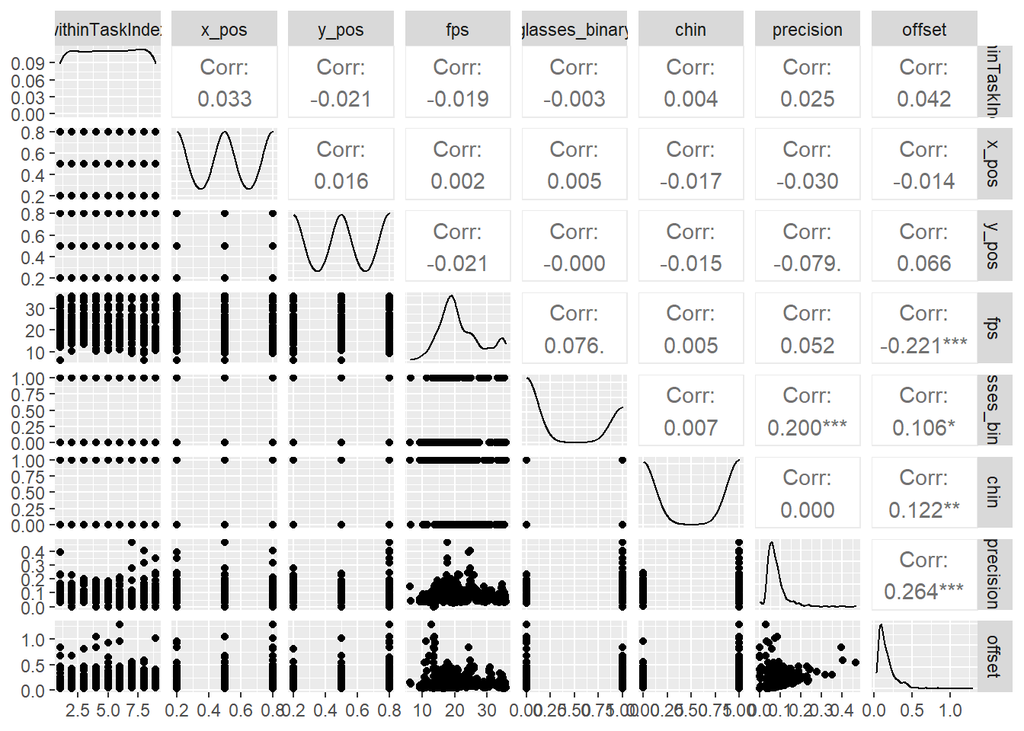

```r
ggpairs(data_trial_fix[, append(predictors, c('precision', 'offset'))]) # Correlations
```

# Models

## IO: intercept only

```r
m_io_0 = gls(
    offset ~ 1,
    data=data_trial_fix,
    method='ML',
    na.action='na.omit'
    )
summary(m_io_0)
```

```
## Generalized least squares fit by maximum likelihood
##   Model: offset ~ 1
##   Data: data_trial_fix
##         AIC       BIC   logLik
##   -581.3003 -572.6196 292.6502
##
## Coefficients:
##                 Value   Std.Error  t-value p-value
## (Intercept) 0.1715003 0.006070141 28.25311       0
##
## Standardized residuals:
##        Min         Q1        Med         Q3        Max
## -0.9893934 -0.6047319 -0.3010154  0.2144501  7.7263891
##
## Residual standard error: 0.1444132
## Degrees of freedom: 567 total; 566 residual
```

## Random intercept

Control for the fact that the subjects start at different places regarding the accuracy of the eyetracking data. Standard error has increased. Subjects vary by about 0.12 (Jan 24) around the intercept. The RI model is way better than the IO model. Therefore, we should do an MLM.

```r
m_ri_0 = lme(
    offset ~ 1,
    data=data_trial_fix,
    method='ML',
    na.action='na.omit',
    random = ~1 | run_id
    )
summary(m_ri_0)
```

```
## Linear mixed-effects model fit by maximum likelihood
##  Data: data_trial_fix
##         AIC       BIC   logLik
##   -990.9456 -977.9245 498.4728
##
## Random effects:
##  Formula: ~1 | run_id
##         (Intercept)   Residual
## StdDev:   0.1240462 0.09004171
##
## Fixed effects: offset ~ 1
##                Value  Std.Error  DF  t-value p-value
## (Intercept) 0.176346 0.02068908 529 8.523627       0
##
## Standardized Within-Group Residuals:
##        Min         Q1        Med         Q3        Max
## -3.8551384 -0.4663952 -0.1123174  0.4118000  5.7505054
##
## Number of Observations: 567
## Number of Groups: 38
```

```r
anova(m_io_0, m_ri_0)
```

```
##        Model df       AIC       BIC   logLik   Test  L.Ratio p-value
## m_io_0     1  2 -581.3003 -572.6196 292.6502
## m_ri_0     2  3 -990.9456 -977.9245 498.4728 1 vs 2 411.6453  <.0001
```